# COVID-19 Leader Perceptions Pilot 2 (Analyses)

November 05, 2020

### Set seed for boxplots

```r
rand_seed = 828
set.seed(rand_seed)
```

# Setup

## Package Loading

```r
library(tidyr)
library(dplyr)
library(Hmisc)
library(stringr)
library(lme4)
library(lmerTest)
library(stats)
library(emmeans)
library(kableExtra)
```

## Data Loading

```r
# Load in data
df <- read.csv("../Data/CLP_Pilot2_Data_Long.csv", header=TRUE,
               stringsAsFactors=FALSE)
```

## Set Factor Levels

```r
# Get rid of vars we won't use
df <- select(df, -contains("OUS"), -contains("covid"), -moral, -redcross_reliable,    # Not used
             -gender, -race, # Recoded
             -trustOther, -trustworthy) # Composite

# Recode the non-numeric variables
df$gender_recode <- factor(df$gender_recode, levels=c("Female", "Male", "Other"))

df$race_recode <- factor(df$race_recode, levels=c("Other", "Asian", "Black", "White"))

df <- df %>% mutate_at(c('age', 'education', 'income', 'religiosity', 'pol_ideology',
                 'support', 'avg_trust'), as.numeric)

# Capitalize scenarios
df <- df %>%
  mutate(dilemma = ifelse(dilemma == "ppe", "PPE", capitalize(dilemma)),
         dilemma = factor(dilemma, levels = c("Lockdown", "Ventilator", "PPE", "Medicine")))

df <- df %>%
  mutate(dimension = recode(dimension, "IH" = "Instrumental Harm",
                            "IB" = "Impartial Beneficence") ,
         dimension = factor(dimension, levels = c("Instrumental Harm", "Impartial Beneficence")))

df <- df %>%
  mutate(argument = factor(argument, levels = c("Utilitarian", "Non-Utilitarian")))
```

### Check Factor Levels

```r
# Dimension
print(unique(df$dimension))
```

```
## [1] Instrumental Harm     Impartial Beneficence
## Levels: Instrumental Harm Impartial Beneficence
```

```r
# Argument
print(unique(df$argument))
```

```
## [1] Non-Utilitarian Utilitarian
## Levels: Utilitarian Non-Utilitarian
```

```r
# Dilemma
print(unique(df$dilemma))
```

```
## [1] Lockdown   Medicine   Ventilator PPE
## Levels: Lockdown Ventilator PPE Medicine
```

## Effect coding

```r
df <- mutate(df,
  argument_recode = recode(argument, "Non-Utilitarian" = -0.5,
                            "Utilitarian" = 0.5),
  dimension_recode = recode(dimension, "Instrumental Harm" = -0.5,
                            "Impartial Beneficence" = 0.5))

# Check
df %>%
  dplyr::select(argument, argument_recode, dimension, dimension_recode) %>%
  unique() %>%
  kable(format = "html", digits = 2) %>%
        kable_styling(bootstrap_options = "striped", full_width = F,
                      position = "left")
```

|  | argument | argument_recode | dimension | dimension_recode |
| --- | --- | --- | --- | --- |
| 1 | Non-Utilitarian | -0.5 | Instrumental Harm | -0.5 |
| 2 | Non-Utilitarian | -0.5 | Impartial Beneficence | 0.5 |
| 4 | Utilitarian | 0.5 | Instrumental Harm | -0.5 |
| 5 | Utilitarian | 0.5 | Impartial Beneficence | 0.5 |

Now the “non-utilitarian” condition is coded as -0.5, and the “utilitarian” condition as 0.5. Now Instrumental Harm is coded as -0.5, and Impartial Beneficence as 0.5.

## Prepare dvs & scale covariates

```r
df_dems <- df %>%
  filter(!is.na(avg_trust)) %>%
  ungroup() %>%
  select(-behav) %>%
  na.omit() %>%
  select(subId, gender_recode, age) %>%
  unique()
```

469 valid subjects

239 females

Mean age: 30.33

### Trust task

```r
df_self <- df %>%
  filter(!is.na(avg_trust)) %>%
  ungroup() %>%
  select(-behav) %>%
  na.omit() %>%
  # Scale
  mutate_at(.funs=list(~ scale(., center = TRUE, scale=FALSE) %>% as.vector),
            vars(age, education, income, religiosity, pol_ideology, support))
```

469 subjects in the self-reported trust task

### Behavioral Task

```r
df_beh <- df %>%
  filter(exclude_behav == 0) %>%
  filter(!is.na(behav)) %>%
  mutate(answer_recode = recode(behav, "Utilitarian" = 1,
                                "Non-Utilitarian" = 0)) %>%
  ungroup() %>%
  select(-avg_trust) %>%
  na.omit() %>%
  # Scale
  mutate_at(.funs=list(~scale(., center = TRUE, scale=FALSE) %>% as.vector),
            vars(age, education, income, religiosity, pol_ideology, support))
```

452 subjects in the voting task

## Set Contrasts

```r
# options("contrasts") # View current contrasts
options(contrasts = c("contr.treatment", "contr.poly")) # Set contrasts
options("contrasts") # Confirm contrasts
```

```
## $contrasts
## [1] "contr.treatment" "contr.poly"
```

## Plot Setup

```r
colorDic <- c("Non-Utilitarian"='#D98A32', "Utilitarian"='#61AAC5')
theme_set(theme_test() +
          theme(legend.position = 'None',
                panel.border = element_blank(),
                plot.title = element_text(hjust = 0.5),
                axis.title = element_text(size = 13, face='bold'),
                axis.title.x = element_text(margin = margin(10, 0, 0, 0)),
                axis.title.y = element_text(margin = margin(0, 10, 0, 0)),
                axis.text.x = element_text(size = 13),
                axis.line.y = element_line(color='gray20'),
                axis.ticks = element_blank(),
                strip.background = element_blank(),
                strip.text = element_text(face = 'bold', size=12),
                panel.spacing = unit(1, "lines")))
```

## Self-reported Trust - Main Model

Here we look at the effects of argument type (non-utilitarian vs utilitarian) and dimension type (instrumental harm vs impartial beneficence), and their interaction, including participant demographics and other covariates.

We use modified contrasts and uses mean-centered covariates. The baseline for gender is “Female”, and for race is “Other”. For argument type, the non-utilitarian is coded as -0.5 and the utilitarian as 0.5. For dimension type, instrumental harm is coded as -0.5, and impartial beneficence as 0.5

```r
trust_model <- lmer(avg_trust ~ gender_recode + age + race_recode + education + income
            + pol_ideology + religiosity + support
            + argument_recode + dimension_recode + argument_recode:dimension_recode
            + (1|subId) + (1|dilemma),
            data = df_self,
            REML = TRUE)

model.output <- summary(trust_model)
model.output <- model.output$coefficients
model.output <- model.output[-1,]
rownames(model.output) <- rownames(model.output) %>%
                                     capitalize() %>%
                                     gsub("_recode", "", .) %>%
                                     gsub("Pol_ideology", "Political Ideology", .) %>%
                                     gsub("support", "Policy Support", .) %>%
                                     gsub('^(Gender)(.*)$', '\\1 [\\2]', .) %>%
                                     gsub('^(Race)(.*)$', '\\1 [\\2]', .) %>%
                                     gsub("Argument:dimension", "Argument x Dimension", .)
colnames(model.output) <- colnames(model.output) %>%
                                     gsub("Estimate", "B", .) %>%
                                     gsub("Std. Error", "SE", .) %>%
                                     gsub("t value", "t", .) %>%
                                     gsub("Pr.*", "p", .)

model.output[, c(1,2,4)] <- round(model.output[, c(1,2,4)], digits = 2)
model.output[, 3] <- round(model.output[, 3], digits = 0)
model.output[, 5] <- format.pval(model.output[, 5], eps = .001, digits = 3)

kable(model.output, format = "html", digits = 2) %>%
        kable_styling(bootstrap_options = "striped", full_width = F,
                      position = "left") %>%
      pack_rows("Covariates", 1, 11) %>%
      pack_rows("Main Effects", 12, 13) %>%
      pack_rows("Interaction", 14, 14)
```

|  | B | SE | df | t | p |
| --- | --- | --- | --- | --- | --- |
| **Covariates** |  |  |  |  |  |
| Gender [Male] | 0.17 | 0.13 | 452 | 1.31 | 0.192 |
| Gender [Other] | 0.07 | 0.33 | 454 | 0.2 | 0.843 |
| Age | 0 | 0.01 | 457 | -0.78 | 0.433 |
| Race [Asian] | 0.14 | 0.21 | 454 | 0.65 | 0.517 |
| Race [Black] | 0.27 | 0.3 | 458 | 0.93 | 0.355 |
| Race [White] | 0.29 | 0.17 | 452 | 1.77 | 0.077 |
| Education | -0.08 | 0.05 | 453 | -1.5 | 0.135 |
| Income | 0.06 | 0.02 | 452 | 2.32 | 0.021 |
| Political Ideology | 0.03 | 0.04 | 456 | 0.8 | 0.424 |
| Religiosity | -0.04 | 0.03 | 452 | -1.08 | 0.283 |
| Support | 0.07 | 0.02 | 868 | 3.12 | 0.002 |
| **Main Effects** |  |  |  |  |  |
| Argument | -0.58 | 0.12 | 452 | -4.75 | <0.001 |
| Dimension | 0.1 | 0.27 | 3 | 0.38 | 0.730 |
| **Interaction** |  |  |  |  |  |
| Argument x Dimension | 2.88 | 0.24 | 452 | 11.8 | <0.001 |

```r
b <- as.numeric(model.output["Argument", "B"])
n <- length(unique(df_self$subId))
se <- as.numeric(model.output["Argument", "SE"])
d <- b/(se*sqrt(n))
```

Cohens’d for Argument main effect: -0.22

```r
b <- as.numeric(model.output["Dimension", "B"])
n <- length(unique(df_self$subId))
se <- as.numeric(model.output["Dimension", "SE"])
d <- b/(se*sqrt(n))
```

Cohens’d for Dimension main effect: 0.02

```r
b <- as.numeric(model.output["Argument x Dimension", "B"])
n <- length(unique(df_self$subId))
se <- as.numeric(model.output["Argument x Dimension", "SE"])
d <- b/(se*sqrt(n))
```

Cohens’d for Argument/Dimension interaction: 0.55

```r
conf <- confint(trust_model, c("argument_recode", "dimension_recode", "argument_recode:dimension_recode"))
```

```
## Computing profile confidence intervals ...
```

```r
kable(conf, format = "html", digits = 2) %>%
        kable_styling(bootstrap_options = "striped", full_width = F,
                      position = "left")
```

|  | 2.5 % | 97.5 % |
| --- | --- | --- |
| argument_recode | -0.82 | -0.35 |
| dimension_recode | -0.41 | 0.62 |
| argument_recode:dimension_recode | 2.41 | 3.35 |

```r
em <- emmeans(trust_model,  specs=c("argument_recode", "dimension_recode"), adjust="bonferroni")
kable(em, format = "html", digits = 2) %>%
        kable_styling(bootstrap_options = "striped", full_width = F,
                      position = "left")
```

| argument_recode | dimension_recode | emmean | SE | df | lower.CL | upper.CL |
| --- | --- | --- | --- | --- | --- | --- |
| -0.5 | -0.5 | 5.16 | 0.24 | 6.71 | 4.35 | 5.96 |
| 0.5 | -0.5 | 3.14 | 0.24 | 6.46 | 2.33 | 3.95 |
| -0.5 | 0.5 | 3.82 | 0.24 | 7.03 | 3.02 | 4.63 |
| 0.5 | 0.5 | 4.68 | 0.24 | 7.22 | 3.88 | 5.48 |

```r
pairs = pairs(em, adjust="bonferroni", by="dimension_recode", reverse=TRUE)
kable(pairs, format = "html", digits = 2) %>%
        kable_styling(bootstrap_options = "striped", full_width = F,
                      position = "left")
```

| contrast | dimension_recode | estimate | SE | df | t.ratio | p.value |
| --- | --- | --- | --- | --- | --- | --- |
| 0.5 - (-0.5) | -0.5 | -2.02 | 0.17 | 454.11 | -11.59 | 0 |
| 0.5 - (-0.5) | 0.5 | 0.86 | 0.17 | 454.56 | 5.00 | 0 |

```r
kable(confint(pairs), format = "html", digits = 2) %>%
        kable_styling(bootstrap_options = "striped", full_width = F,
                      position = "left")
```

| contrast | dimension_recode | estimate | SE | df | lower.CL | upper.CL |
| --- | --- | --- | --- | --- | --- | --- |
| 0.5 - (-0.5) | -0.5 | -2.02 | 0.17 | 454.11 | -2.36 | -1.68 |
| 0.5 - (-0.5) | 0.5 | 0.86 | 0.17 | 454.56 | 0.52 | 1.19 |

## Self-reported Trust - Figures

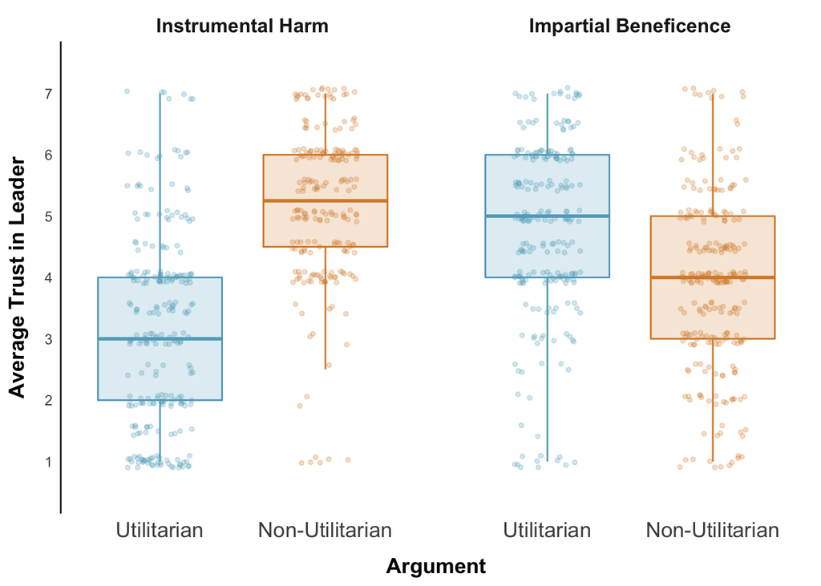

```r
df_self %>%
  ggplot(aes(x=argument, y=avg_trust,
             color=argument, fill=argument)) +
  geom_jitter(alpha=.25, width = .2, height = .1, size=1) +
  geom_boxplot(alpha=.2, size=.5, outlier.shape = NA) +
  scale_fill_manual(values = colorDic) +
  scale_color_manual(values = colorDic) +
  facet_wrap(~dimension) +
  xlab('Argument') +
  ylab('Average Trust in Leader') +
  scale_y_continuous(breaks = seq(1, 7), limits = c(0.5, 7.5)) +
  theme() -> p

p
```

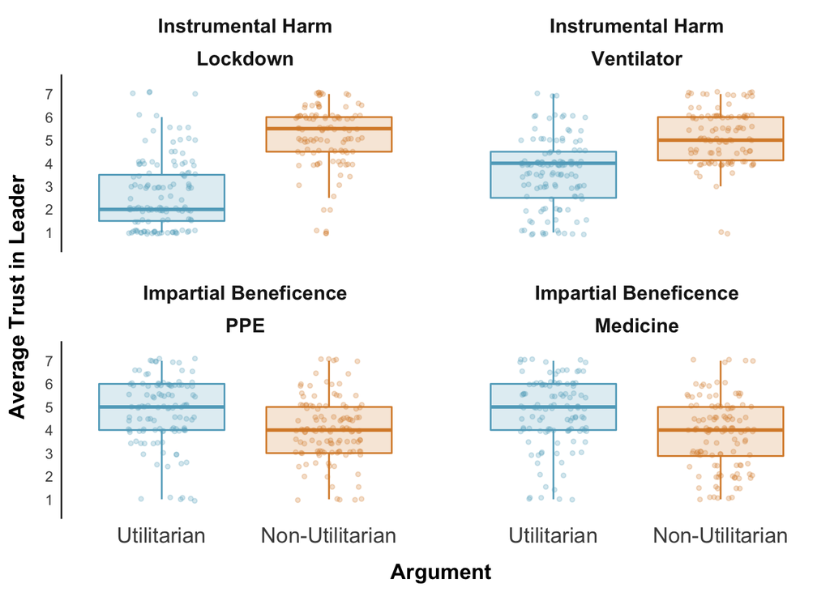

```r
ggsave(plot=p, width = 6, height = 4, device='jpeg',
       filename="../Plots/CLP_Pilot2_Analysis_Plot.jpeg")
ggsave(plot=p, width = 6, height = 4, device='pdf',
       filename="../Plots/CLP_Pilot2_Analysis_Plot.pdf")

df_self %>%
  ggplot(aes(x=argument, y=avg_trust,
             color=argument, fill=argument)) +
  geom_jitter(alpha=.25, width = .2, height = .1, size=1) +
  geom_boxplot(alpha=.2, size=.5, outlier.shape = NA) +
  scale_fill_manual(values = colorDic) +
  scale_color_manual(values = colorDic) +
  facet_wrap(~dimension*dilemma) +
  xlab('Argument') +
  ylab('Average Trust in Leader') +
  scale_y_continuous(breaks = seq(1, 7), limits = c(0.5, 7.5)) -> p

p
```

```r
ggsave(plot=p, width = 6, height = 6, device='jpeg',
       filename="../Plots/CLP_Pilot2_Analysis_Plot_byDil.jpeg")
ggsave(plot=p, width = 6, height = 6, device='pdf',
       filename="../Plots/CLP_Pilot2_Analysis_Plot_byDil.pdf")
```

## Behavioral Task

Here we look at the effects of dimension type (instrumental harm vs impartial beneficence), on leader choice (non-utilitarian vs utilitarian), including participant demographics and other covariates.

We use modified contrasts and uses mean-centered covariates. The baseline for gender is “Female”, and for race is “Other”. For argument type, the non-utilitarian is coded as -0.5 and the utilitarian as 0.5. For dimension type, instrumental harm is coded as -0.5, and impartial beneficence as 0.5

```r
beh_model <- glmer(answer_recode ~ gender_recode + age + race_recode + education + income
               + pol_ideology + religiosity + support
               + dimension_recode + (1|dilemma),
               data=df_beh,  family=binomial(link = "logit"))
```

```
## boundary (singular) fit: see ?isSingular
```

```r
model.output <- summary(beh_model)
model.output <- model.output$coefficients
model.output <- model.output[-1,]
rownames(model.output) <- rownames(model.output) %>%
                                     capitalize() %>%
                                     gsub("_recode", "", .) %>%
                                     gsub("Pol_ideology", "Political Ideology", .) %>%
                                     gsub("support", "Policy Support", .) %>%
                                     gsub('^(Gender)(.*)$', '\\1 [\\2]', .) %>%
                                     gsub('^(Race)(.*)$', '\\1 [\\2]', .)
colnames(model.output) <- colnames(model.output) %>%
                                     gsub("Estimate", "B", .) %>%
                                     gsub("Std. Error", "SE", .) %>%
                                     gsub("z value", "z", .) %>%
                                     gsub("Pr.*", "p", .)

model.output[, 1:3] <- round(model.output[, 1:3], digits = 2)
model.output[, 4] <- format.pval(model.output[, 4], eps = .001, digits = 3)

kable(model.output, format = "html", digits = 2) %>%
        kable_styling(bootstrap_options = "striped", full_width = F,
                      position = "left") %>%
pack_rows("Covariates", 1, 11) %>%
pack_rows("Main Effects", 12, 12)
```

|  | B | SE | z | p |
| --- | --- | --- | --- | --- |
| **Covariates** |  |  |  |  |
| Gender [Male] | 0 | 0.31 | 0.01 | 0.995 |
| Gender [Other] | -0.54 | 0.95 | -0.57 | 0.570 |
| Age | -0.01 | 0.01 | -0.36 | 0.716 |
| Race [Asian] | -0.46 | 0.56 | -0.82 | 0.410 |
| Race [Black] | 0.18 | 0.75 | 0.24 | 0.810 |
| Race [White] | -0.19 | 0.4 | -0.47 | 0.641 |
| Education | 0.05 | 0.12 | 0.38 | 0.706 |
| Income | -0.01 | 0.06 | -0.12 | 0.904 |
| Political Ideology | -0.2 | 0.11 | -1.9 | 0.057 |
| Religiosity | 0.02 | 0.09 | 0.25 | 0.803 |
| Support | 1.02 | 0.1 | 10.28 | <0.001 |
| **Main Effects** |  |  |  |  |
| Dimension | 2.41 | 0.33 | 7.3 | <0.001 |

```r
b <- as.numeric(model.output["Dimension", "B"])
or <- exp(b)
d <- log(or)*sqrt(3)/pi
```

Odds ratio: 11.13

Cohens’d for Dimension main effect: 1.33

```r
conf <- confint(beh_model, "dimension_recode")
```

```
## Computing profile confidence intervals ...
```

```r
kable(conf, format = "html", digits = 2) %>%
        kable_styling(bootstrap_options = "striped", full_width = F,
                      position = "left")
```

|  | 2.5 % | 97.5 % |
| --- | --- | --- |
| dimension_recode | 1.77 | 3.13 |

```r
em <- emmeans(beh_model,  specs=c("dimension_recode"),
              adjust="bonferroni", type = "response")
kable(em, format = "html", digits = 2) %>%
        kable_styling(bootstrap_options = "striped", full_width = F,
                      position = "left")
```

| dimension_recode | prob | SE | df | asymp.LCL | asymp.UCL |
| --- | --- | --- | --- | --- | --- |
| -0.5 | 0.15 | 0.05 | Inf | 0.06 | 0.31 |
| 0.5 | 0.65 | 0.08 | Inf | 0.46 | 0.81 |

To make sure the singularity is not an issue, check a simplified model:

```r
beh_model <- glm(answer_recode ~ gender_recode + age + race_recode + education + income
               + pol_ideology + religiosity + support
               + dimension_recode,
               data=df_beh,  family=binomial(link = "logit"))

model.output <- summary(beh_model)
model.output <- model.output$coefficients
model.output <- model.output[-1,]
rownames(model.output) <- rownames(model.output) %>%
                                     capitalize() %>%
                                     gsub("_recode", "", .) %>%
                                     gsub("Pol_ideology", "Political Ideology", .) %>%
                                     gsub("support", "Policy Support", .) %>%
                                     gsub('^(Gender)(.*)$', '\\1 [\\2]', .) %>%
                                     gsub('^(Race)(.*)$', '\\1 [\\2]', .)
colnames(model.output) <- colnames(model.output) %>%
                                     gsub("Estimate", "B", .) %>%
                                     gsub("Std. Error", "SE", .) %>%
                                     gsub("z value", "z", .) %>%
                                     gsub("Pr.*", "p", .)

model.output[, 1:3] <- round(model.output[, 1:3], digits = 2)
model.output[, 4] <- format.pval(model.output[, 4], eps = .001, digits = 3)

kable(model.output, format = "html", digits = 2) %>%
        kable_styling(bootstrap_options = "striped", full_width = F,
                      position = "left") %>%
pack_rows("Covariates", 1, 11) %>%
pack_rows("Main Effects", 12, 12)
```

|  | B | SE | z | p |
| --- | --- | --- | --- | --- |
| **Covariates** |  |  |  |  |
| Gender [Male] | 0 | 0.31 | 0.01 | 0.995 |
| Gender [Other] | -0.54 | 0.95 | -0.57 | 0.570 |
| Age | -0.01 | 0.01 | -0.36 | 0.716 |
| Race [Asian] | -0.46 | 0.56 | -0.82 | 0.410 |
| Race [Black] | 0.18 | 0.75 | 0.24 | 0.810 |
| Race [White] | -0.19 | 0.4 | -0.47 | 0.641 |
| Education | 0.05 | 0.12 | 0.38 | 0.706 |
| Income | -0.01 | 0.06 | -0.12 | 0.904 |
| Political Ideology | -0.2 | 0.11 | -1.9 | 0.057 |
| Religiosity | 0.02 | 0.09 | 0.25 | 0.803 |
| Support | 1.02 | 0.1 | 10.28 | <0.001 |
| **Main Effects** |  |  |  |  |
| Dimension | 2.41 | 0.33 | 7.3 | <0.001 |

## Behavioral Task - Figure

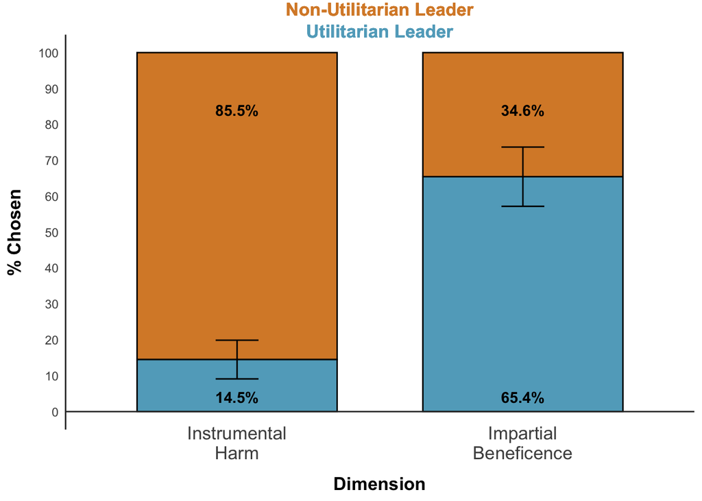

```r
summary(em) %>%
  mutate(`Non-Utilitarian`=1-prob, `Utilitarian`=prob) %>%
  gather(Argument, perc, -(dimension_recode:asymp.UCL)) %>%
  mutate(perc = perc*100,
         se_perc = SE*100,
            dimension = recode(dimension_recode, `-0.5` = "Instrumental Harm",
                                       `0.5` = "Impartial Beneficence"),
            dimension = factor(str_replace(dimension, " ", "\n"),
                                      levels=c("Instrumental\nHarm", "Impartial\nBeneficence")),
            lab_ypos = recode(Argument, 'Utilitarian' = 4, 'Non-Utilitarian' = 80)) -> df_beh_plot

df_beh_plot %>%
  ggplot(aes(x=dimension, y=perc, fill=Argument)) +
  geom_bar(stat="identity", color='black',
           width = .7) +
  geom_errorbar(data=filter(select(df_beh_plot, Argument, dimension, perc, se_perc), Argument=="Utilitarian"),
                    aes(ymin=perc-se_perc, ymax=perc+se_perc), width = 0.15) +
  scale_fill_manual(values = colorDic)  +
  theme(axis.ticks.y = element_blank()) +
  xlab('Dimension') +
  ylab('% Chosen') +
  scale_y_continuous(breaks = seq(0, 100, 10), limits = c(0, 100)) +
  coord_cartesian(clip = 'off') +
  geom_hline(yintercept = 0, color = 'gray20') +
  geom_text(aes(x = 1.5, y = Inf, label ="Non-Utilitarian Leader",
                 vjust=-1.5, size=4, fontface =2), color=colorDic[1]) +
  geom_text(aes(x = 1.5, y = Inf, label ="Utilitarian Leader",
                 vjust=.2, size=4, fontface =2),color=colorDic[2]) +
  geom_text(aes(y=lab_ypos, label=paste(round(perc, 1), '%', sep='')), fontface =2,
            stat="identity",
            position = position_stack(vjust = 1)) +
  theme(plot.margin = unit(c(25, 5.5, 5.5, 5.5), "points"),
        axis.text.x = element_text(margin=margin(-5, 0, 0, 0))) -> p

p
```

```r
ggsave(plot=p, width = 3.5, height = 5, device='jpeg',
       filename="../Plots/CLP_Pilot2_Analysis_Plot_Beh.jpeg")
ggsave(plot=p, width = 3.5, height = 5, device='pdf',
       filename="../Plots/CLP_Pilot2_Analysis_Plot_Beh.pdf")
```